# Algorithmic Fairness: Considering Different Definitions

## Introduction

Decision making within the United States criminal justice system relies heavily on risk assessment, which determines the potential risk that a released defendant will fail to appear in court or cause harm to the public. Judges use these assessments to decide if bail can be set or if a defendant should be detained before trial. While this is not new in the legal system, the use of risk scores determined by an algorithm are gaining prevalence and support. Proponents promote the use of risk scores to guide judges in their decision making, arguing that machine learning could lead to greater efficiency, accountability, and less biased decisions compared with human judgment ([Henry](https://theappeal.org/risk-assessment-explained/)). On the other hand, critical voices raise the concern that biases can creep into these algorithms at any point in the process, and that algorithms are often applied to the wrong situations ([Henry](https://theappeal.org/risk-assessment-explained/)). Further, they exacerbate the racism embedded deep within the criminal justice system by perpetuating inequalities found in historical data ([Henry](https://theappeal.org/risk-assessment-explained/)).

In the debate about the use of risk assessment algorithms, people have used data analysis to determine the extent to which these algorithms are fair to different groups of people. In this homework, **you will explore some of the many definitions and metrics (different ways of operationalizing data to quantify those definitions) of fairness that can be applied to the risk assessment tool COMPAS**. In doing so, you will understand and provide evidence for or against the presence of bias within the algorithm. You will examine the arguments and analyses made by the company that created COMPAS and the critics of this risk assessment tool to gain a deeper understanding of the technical and societal interpretations and implications of fairness.

**NOTE**: When we discuss bias here, we define it most generally as prejudice or an inclination in favor of one person, thing, or group compared to another. In the context of machine learning, bias is a “phenomenon that occurs when an algorithm produces results that are systemically prejudiced due to erroneous assumptions in the machine learning process” ([Rouse](https://searchenterpriseai.techtarget.com/definition/machine-learning-bias-algorithm-bias-or-AI-bias#:~:text=Machine%20learning%20bias%2C%20also%20sometimes,in%20the%20machine%20learning%20process)).

## Table of Contents:

- Part 0. COMPAS
- Part 1. ProPublica's Perspective
- Part 2. Northpointe's Perspective
- Part 3. Another Definition of Fairness

## Setup

Let's begin by importing the packages we need.

```python
import numpy as np
import pandas as pd
from sklearn.linear_model import LogisticRegression
from sklearn.metrics import roc_curve, roc_auc_score
import matplotlib.pyplot as plt
import seaborn as sns
!pip install aif360
!pip install BlackBoxAuditing
from aif360.algorithms.preprocessing import DisparateImpactRemover
from aif360.datasets import BinaryLabelDataset
```

[output not shown]

# Part 0. COMPAS: Why it was created and how it exists in the court system

COMPAS (Correctional Offender Management Profiling for Alternative Sanctions) is a commercial tool produced by the for-profit company Northpointe (acquired by equivant) known as a recidivism risk assessment system. **Tools like COMPAS are used to predict the risk of future crimes for an individual who has entered the US criminal justice system by outputting a risk score from 1-10**. While COMPAS was initially intended to aid decisions made by probation officers on treatment and supervision of those who are incarcerated, Northpointe has since emphasized the scalability of the tool to “fit the needs of many different decision points” including pre-screening assessments, pretrial release decisions (whether or not to hold an arrested individual in jail until their trial), and post-trial next steps for the defendant ([Northpointe](http://www.northpointeinc.com/files/downloads/FAQ_Document.pdf)). These algorithms are believed by many to provide the ability to make the court system more just by removing or correcting for bias of criminal justice officials.

### Question 0a

Explain 3 parties that are impacted by the COMPAS tool. In what ways are they impacted? (Can you think of impacts beyond those in the courtroom for at least one of your examples?)

> Three parties impacted by the COMPAS tool are the prisoners because they are the victims of the tool and their lives are on the lines being determined whether they are out of prison or not; the probation officers as the paragraph said because the tool aids them on how to treat and supervise prisoners; and the judges because they are the ones making the "final" decision for these prisoners.

### Question 0b

Based on your initial reading, what is one problem of the criminal justice system that the COMPAS tool could potentially alleviate? What is one potential problem that using the COMPAS algorithm could introduce?

> One problem that the COMPAS tool could potentially alleviate is to prevent further crimes to be committed by the prisoners. One potetnail problem that COMPAS could introduce is that to make sure people are not committing a crime a second time, surveillance may be needed for those who COMPAS determined that they will even though it may not be true.

## Dataset Setup

We will be using the data that was obtained and used by ProPublica in their own analysis of the COMPAS tool from Broward County public records of people who were scored between 2013 and 2014 ([ProPublica](https://www.propublica.org/article/how-we-analyzed-the-compas-recidivism-algorithm)). In order to replicate ProPublica's analysis, we remove any cases where the charge was not within 30 days of the score (ProPublica did this in order to match the COMPAS score with the correct criminal case). We are left with 6172 rows in the dataset.

```python
data = pd.read_csv('compas-scores-two-years.csv')
data = data.query('days_b_screening_arrest <= 30 & days_b_screening_arrest >= -30')
data
```

|  | id | name | first | last | compas_screening_date | sex | dob | age | age_cat | race | ... | v_decile_score | v_score_text | v_screening_date | in_custody | out_custody | priors_count.1 | start | end | event | two_year_recid |
| --- | --- | --- | --- | --- | --- | --- | --- | --- | --- | --- | --- | --- | --- | --- | --- | --- | --- | --- | --- | --- | --- |
| 0 | 1 | miguel hernandez | miguel | hernandez | 2013-08-14 | Male | 1947-04-18 | 69 | Greater than 45 | Other | ... | 1 | Low | 2013-08-14 | 2014-07-07 | 2014-07-14 | 0 | 0 | 327 | 0 | 0 |
| 1 | 3 | kevon dixon | kevon | dixon | 2013-01-27 | Male | 1982-01-22 | 34 | 25 - 45 | African-American | ... | 1 | Low | 2013-01-27 | 2013-01-26 | 2013-02-05 | 0 | 9 | 159 | 1 | 1 |
| 2 | 4 | ed philo | ed | philo | 2013-04-14 | Male | 1991-05-14 | 24 | Less than 25 | African-American | ... | 3 | Low | 2013-04-14 | 2013-06-16 | 2013-06-16 | 4 | 0 | 63 | 0 | 1 |
| 5 | 7 | marsha miles | marsha | miles | 2013-11-30 | Male | 1971-08-22 | 44 | 25 - 45 | Other | ... | 1 | Low | 2013-11-30 | 2013-11-30 | 2013-12-01 | 0 | 1 | 853 | 0 | 0 |
| 6 | 8 | edward riddle | edward | riddle | 2014-02-19 | Male | 1974-07-23 | 41 | 25 - 45 | Caucasian | ... | 2 | Low | 2014-02-19 | 2014-03-31 | 2014-04-18 | 14 | 5 | 40 | 1 | 1 |
| ... | ... | ... | ... | ... | ... | ... | ... | ... | ... | ... | ... | ... | ... | ... | ... | ... | ... | ... | ... | ... | ... |
| 7209 | 10996 | steven butler | steven | butler | 2013-11-23 | Male | 1992-07-17 | 23 | Less than 25 | African-American | ... | 5 | Medium | 2013-11-23 | 2013-11-22 | 2013-11-24 | 0 | 1 | 860 | 0 | 0 |
| 7210 | 10997 | malcolm simmons | malcolm | simmons | 2014-02-01 | Male | 1993-03-25 | 23 | Less than 25 | African-American | ... | 5 | Medium | 2014-02-01 | 2014-01-31 | 2014-02-02 | 0 | 1 | 790 | 0 | 0 |
| 7211 | 10999 | winston gregory | winston | gregory | 2014-01-14 | Male | 1958-10-01 | 57 | Greater than 45 | Other | ... | 1 | Low | 2014-01-14 | 2014-01-13 | 2014-01-14 | 0 | 0 | 808 | 0 | 0 |
| 7212 | 11000 | farrah jean | farrah | jean | 2014-03-09 | Female | 1982-11-17 | 33 | 25 - 45 | African-American | ... | 2 | Low | 2014-03-09 | 2014-03-08 | 2014-03-09 | 3 | 0 | 754 | 0 | 0 |
| 7213 | 11001 | florencia sanmartin | florencia | sanmartin | 2014-06-30 | Female | 1992-12-18 | 23 | Less than 25 | Hispanic | ... | 4 | Low | 2014-06-30 | 2015-03-15 | 2015-03-15 | 2 | 0 | 258 | 0 | 1 |

6172 rows × 53 columns

We are also able to filter out any information that was not used by ProPublica and select fields for severity of charge, number of priors, demographics, age, sex, compas scores, and whether each person was accused of a crime within two years.

```python
select_data = data[["age", "c_charge_degree", "race", "age_cat", "score_text", "sex", "priors_count",
                    "days_b_screening_arrest", "decile_score", "is_recid", "two_year_recid", "c_jail_in", "c_jail_out"]]
```

```python
select_data
```

|  | age | c_charge_degree | race | age_cat | score_text | sex | priors_count | days_b_screening_arrest | decile_score | is_recid | two_year_recid | c_jail_in | c_jail_out |
| --- | --- | --- | --- | --- | --- | --- | --- | --- | --- | --- | --- | --- | --- |
| 0 | 69 | F | Other | Greater than 45 | Low | Male | 0 | -1.0 | 1 | 0 | 0 | 2013-08-13 06:03:42 | 2013-08-14 05:41:20 |
| 1 | 34 | F | African-American | 25 - 45 | Low | Male | 0 | -1.0 | 3 | 1 | 1 | 2013-01-26 03:45:27 | 2013-02-05 05:36:53 |
| 2 | 24 | F | African-American | Less than 25 | Low | Male | 4 | -1.0 | 4 | 1 | 1 | 2013-04-13 04:58:34 | 2013-04-14 07:02:04 |
| 5 | 44 | M | Other | 25 - 45 | Low | Male | 0 | 0.0 | 1 | 0 | 0 | 2013-11-30 04:50:18 | 2013-12-01 12:28:56 |
| 6 | 41 | F | Caucasian | 25 - 45 | Medium | Male | 14 | -1.0 | 6 | 1 | 1 | 2014-02-18 05:08:24 | 2014-02-24 12:18:30 |
| ... | ... | ... | ... | ... | ... | ... | ... | ... | ... | ... | ... | ... | ... |
| 7209 | 23 | F | African-American | Less than 25 | Medium | Male | 0 | -1.0 | 7 | 0 | 0 | 2013-11-22 05:18:27 | 2013-11-24 02:59:20 |
| 7210 | 23 | F | African-American | Less than 25 | Low | Male | 0 | -1.0 | 3 | 0 | 0 | 2014-01-31 07:13:54 | 2014-02-02 04:03:52 |
| 7211 | 57 | F | Other | Greater than 45 | Low | Male | 0 | -1.0 | 1 | 0 | 0 | 2014-01-13 05:48:01 | 2014-01-14 07:49:46 |
| 7212 | 33 | M | African-American | 25 - 45 | Low | Female | 3 | -1.0 | 2 | 0 | 0 | 2014-03-08 08:06:02 | 2014-03-09 12:18:04 |
| 7213 | 23 | F | Hispanic | Less than 25 | Low | Female | 2 | -2.0 | 4 | 1 | 1 | 2014-06-28 12:16:41 | 2014-06-30 11:19:23 |

6172 rows × 13 columns

### Question 0c

Explore the dataset. What is the granularity of this dataset?

> I think this dataset is very detailed because it provides the date and time when the people using the tool were using it as well as the dates they have been in prison.

*Sensitive features* are attributes within a dataset that are given special consideration and treatment for potential legal, social, or ethical reasons. Often, these features are recognized and protected by antidiscrimination or privacy laws. One example of a sensitive feature is age.

### Question 0d

Identify 2 sensitive features in the dataset that we have not already mentioned.

> Race and sex

### Question 0e

Pick one of the sensitive features you have identified. What features are proxies for that sensitive feature?

> For the sensitive feature race, a proxy for it can be their name. Sometimes it is not the case but many times name is related to what race you are from.

### Question 0f

As a data scientist, why is it important to give special consideration to these kinds of features?

> Because these might obscure the bias of the data.

# Part 1. ProPublica’s Perspective

### Who is ProPublica?

ProPublica is a nonprofit organization that “produces investigative journalism with moral force” ([ProPublica](https://www.propublica.org/about/)). ProPublica was founded as a nonpartisan newsroom aiming to expose and question abuses of power, justice, and public trust, often by systems and institutions deeply ingrained in the US.

In 2016, ProPublica investigated the COMPAS algorithm to assess the accuracy of and potential racial bias within the tool, as it became more popular within the United States court system nationwide. In their analysis, ProPublica used data from defendants with risk scores from Broward County, FL from 2013 to 2014 to test for statistical differences in outcomes for Black and white defendants, which ultimately highlighted racial disparities that exist within the algorithm. ProPublica came to the conclusion that COMPAS utilizes data from a criminal justice system with a history of racial injustices, thus continuing to disproportionately target and arrest Black people in comparison to their white counterparts. While the COMPAS algorithm’s treats unequal groups alike, which may appear neutral, ProPublica’s data analysis and reporting emphasized the bias against Black defendants and their communities that COMPAS produced from this line of thinking, a claim that Northpointe has disputed (as we will see later).

Let's retrace ProPublica's statistical analysis in order to better understand ProPublica's argument and engage with the metric of fairness that it uses.

## Question 1. Logistic Regression: What are the odds of getting a high risk score?

ProPublica’s first attempt at understanding the disparity in risk scores from the COMPAS tool was through logistic regression to model the chance of getting a “higher” (i.e. more "risky") score. COMPAS labels scores 1-4 as low, 5-7 as medium, and 8-10 as high scores. For the purposes of their analysis, ProPublica labeled any score above a low score as high.

### Question 1a (i)

Create a logistic regression model to predict the score of defendants based on their sex, age, race, previous arrests, seriousness of the crime, and future criminal behavior. Please be sure to:

- standard scale your inputs
- one-hot encode categorical inputs (hint: pd.get_dummies() is a useful function!)

For the purposes of this notebook, do not worry about cross-validation or parameter selection. Please use the default LogisticRegression object (already imported at the top).

```python
# Create logistic regression model
# Student Code Here
from sklearn.preprocessing import StandardScaler
from sklearn.model_selection import train_test_split
from sklearn.metrics import accuracy_score

# Get feature and target columns
feature_columns = ['age', 'sex_Female','sex_Male', 'race_African-American', 'race_Asian','race_Caucasian', 'race_Hispanic', 'race_Native American',  'race_Other', 'priors_count', 'c_charge_degree_F', 'c_charge_degree_M']
target_column = 'score'

# Create a DataFrame with one-hot encoded categorical inputs
df = pd.get_dummies(data=select_data, columns=['sex','race','c_charge_degree'])

# Create a new column 'score' which stores a 1 if the decile score is > 4, 0 otherwise
high = df['decile_score'] > 4
low = df['decile_score'] <= 4

df.loc[high, 'score'] = df.loc[high, 'decile_score'].apply(lambda x: x > 4)
df.loc[low, 'score'] = df.loc[low, 'decile_score'].apply(lambda x: x > 4)
df['score'] = df['score'].astype('int')
df = df.reset_index(drop =True)

# Standard scale inputs
scaler = StandardScaler()
scaler.fit(df[feature_columns])

# Split data with test size 20%
X_train, X_test, y_train, y_test = train_test_split(
    df[feature_columns],
    df[target_column],
    test_size=0.2)

# Create LogisticRegression object and use fit
model = LogisticRegression()
model.fit(X_train, y_train)

# Predict the data
predictions = model.predict(X_test)
predictions
```

[output not shown]

```
array([1, 1, 0, ..., 1, 1, 1])
```

```python
# Print accuracy score
print(accuracy_score(predictions, y_test))
# 0.31417004048582997
# 0.7692307692307693 after using 'score' column with 0s and 1s
```

```
0.7303643724696356
```

### Question 1a (ii)

Print out the coefficients paired with the corresponding feature names.

```python
# Pair the coefficients with feature names
# Student Code Here
coef_dict = {}
for coef, feat in zip(model.coef_[0],feature_columns):
    coef_dict[feat] = coef
print(coef_dict)
```

[output not shown]

### Question 1b

What features are most predictive?

### Question 1c

Are Black defendants more likely to get a high risk score opposed to white defendants? If so, by how much? Show your calculations.

```python
# Student Calculations Here

# Create a new df that contains the predictions
df_predicted = df.iloc[X_test.index.tolist()]
df_predicted['predicted score'] = predictions

# Check how many individuals who are black scored a 1
black_df_predict = df_predicted[df_predicted['race_African-American'] == 1]
total_black = black_df_predict.count()['race_African-American']
count_black = black_df_predict[black_df_predict['predicted score'] == 1].count()['predicted score']

print("Black defendants who got a high risk score: ", (count_black/total_black)*100)

# Check how many individuals who are white sscored a 1
white_df_predict = df_predicted[df_predicted['race_Caucasian'] == 1]
total_white = white_df_predict.count()['race_Caucasian']
count_white = white_df_predict[white_df_predict['predicted score'] == 1].count()['predicted score']

print("White defendants who got a high risk score: ", (count_white/total_white)*100)
```

```
Black defendants who got a high risk score:  64.09017713365539
White defendants who got a high risk score:  20.763723150357997
```

[output not shown]

## Question 2. FPR and FNR: Does COMPAS overpredict or underpredict across groups?

In order to answer this question and understand the ways in which bias is present in the risk scores, ProPublica used the False Positive Rate (FPR) and False Negative Rate (FNR) as their metrics to understand and quantify fairness.

### Question 2a

Complete the following functions to calculate the FPR and FNR. Afterwards, apply these functions to each racial subgroup: Black defendants and white defendants. Keep in mind that ProPublica defines a high score as anything above 4, and therefore a false positive would be a defendant with a high score who did not recidivate.

```python
from sklearn.metrics import confusion_matrix

# tn, fp, fn, tp = confusion_matrix(y_test, predictions).ravel()
# df['decile_score'], df['two_year_recid']

def fpr(race_feature, data):
    # Return the False Positive Rate of scores for the specified race_feature
    # fp/(fp+tn)
    df_p = data[data[race_feature] == 1]
    tn, fp, fn, tp = confusion_matrix(df_p['two_year_recid'], df_p['predicted score']).ravel()
    fpr = fp/(fp+tn)
    return fpr


def fnr(race_feature, data):
    # Return the False Negative Rate of scores for the specified race_feature
    # fn/(tp+fn)
    df_p = data[data[race_feature] == 1]
    tn, fp, fn, tp = confusion_matrix(df_p['two_year_recid'], df_p['predicted score']).ravel()
    fnr = fn/(tp+fn)
    return fnr
```

```python
# Apply the metrics to the dataset - Replace zeros with correct metrics
print("FPR for Black defendants:", fpr("race_African-American", df_predicted))
print("FPR for white defendants:", fpr("race_Caucasian", df_predicted))
print("FNR for Black defendants:", fnr("race_African-American", df_predicted))
print("FNR for white defendants:", fnr("race_Caucasian", df_predicted))
```

```
FPR for Black defendants: 0.49477351916376305
FPR for white defendants: 0.1349206349206349
FNR for Black defendants: 0.23353293413173654
FNR for white defendants: 0.6826347305389222
```

### Question 2b

What can you conclude from these metrics about the overprediction of risk scores for Black and white defendants? By how much is the tool overpredicting? (Hint: Look at your calculations for the FPR.)

```python
# Calculation of ratio for FPR
fpr("race_African-American", df_predicted)/fpr("race_Caucasian", df_predicted)
```

```
3.6671449067431854
```

> The tool is overpredicting by over 300%. We can conclude that for African American defendants, the tool is overpredicting about 300% more than White defendants

### Question 2c

What can you conclude from these metrics about the underprediction of risk scores for Black and white defendants? By how much is the tool underpredicting? (Hint: Look at your calculations for the FNR.)

```python
# Calculation of ratio for FNR
fnr("race_African-American", df_predicted)/fnr("race_Caucasian", df_predicted)
```

```
0.32465882233347737
```

### Question 2d

What is the importance of overprediction and underprediction in regard to ProPublica’s analysis? How might these observations have real impacts on the defendants who receive scores?

> The importance of overprediction and underprediction in regard to ProPublica's analysis is that for ProPublica's analysis, they mean that the tool is completely wrong if you overpredit or underpredict because you cannot do that when lives are at stakes. These observations have real impacts on the defendants who receive these scores because these scores will basically determine how their sentence will turn out and how it will impact society.

## Question 3.

### Question 3a (i)

Utilizing your answers from 1b and 2b, what problems does ProPublica highlight in the COMPAS algorithm?

> It highlights the inclusion of sensitive feature in their data collection.

### Question 3a (ii)

How would you describe ProPublica’s definition of fairness, after learning and utilizing the metrics they used?

> I would describe fairness as including results from their false positives and false negatives instead of fully focusing on the true positives and true negatives.

### Question 3b

Why did ProPublica choose to investigate bias between races rather than a different sensitive feature? (Hint: think about how ProPublica’s conclusions reflect the racial disparities in our current criminal justice system.)

> I think ProPublica chose to investigate this because their main goal for their journalism is to expose and question topics like the racial disparities in our criminal justice system. Their conclusions show that there is actually a racial disparity in the criminal justice system by showing how the tool that many of these legal institutions use reflect on their thinking.

### Question 3c

What is ProPublica’s agenda as an investigative journalism organization? How do we see this in their analysis and conclusions?

> ProPublics's agenda, as stated before, is "to expose and question abuses of power, justice, and public trust, often by systems and institutions deeply ingrained in the US." We can see this in their analysis and conclusions in the way that their argument is that the tool used by some legal institutions in the US is being unfair or unjust to some society groups, ie, Black individuals.

We mentioned earlier that Northpointe disagreed with ProPublica's argument that the COMPAS algorithm is racially biased. Now that we’ve analyzed ProPublica’s perspective and seen the way in which they define and operationalize the concept of fairness, let’s move on to Northpointe’s.

# Part 2. Northpointe's Perspective

### Who is Northpointe?

Northpointe (merged with two other companies to create *equivant* in 2017) is a for-profit computer software company that aims to advance justice by informing and instilling confidence in decision makers at every stage of the criminal justice system ([equivant](https://www.equivant.com/)). In addition to operating and continuing to develop COMPAS, *equivant* has developed a variety of technologies for use in court case management, attorney case management, inmate classification, and risk/needs assessment strategies.

In the wake of criticism from ProPublica and other researchers alike, Northpointe produced a [detailed response](http://go.volarisgroup.com/rs/430-MBX-989/images/ProPublica_Commentary_Final_070616.pdf) to ProPublica’s allegations, claiming that these critiques of their tool utilized the wrong type of classification statistics in their analysis and portrayed the tool incorrectly. The company provided their own analysis of the COMPAS algorithm by using different statistical methods and responding individually to each of ProPublica’s claims of racial bias against Black defendants.

Upon examining their tool’s fairness through accuracy equity and predictive parity (which are metrics that were left out of ProPublica’s analysis), as well as the fact that the model was not trained with a race feature, Northpointe concluded that their algorithm treats all citizens and specified groups equally, and therefore does not exhibit signs of bias or inequality for specified groups. Now, let’s take a look at how Northpointe supported this argument.

## Question 4. Accuracy Equity: Is each group being discriminated against equally?

Instead of analyzing and comparing the model errors FNR and FPR, Northpointe utilized the complement of FNR, known as the TPR (or what is often referred to as *Sensitivity*), paired with the FPR to prove what they refer to as *Accuracy Equity* through the use of a *ROC Curve*. Accuracy equity, according to [Northpointe](http://go.volarisgroup.com/rs/430-MBX-989/images/ProPublica_Commentary_Final_070616.pdf), is exhibited in the model “if it can discriminate recidivists and nonrecidivists equally well for two different groups such as blacks and whites.” Recall that we use ROC curves and the *Area Under the Curve* to understand how much a model is capable of distinguishing between classes.

### Question 4a

Utilize the sklearn metrics package to calculate TPR and FPR, visualize the ROC curve for both white and Black defendants, and calculate the AUC for each curve.

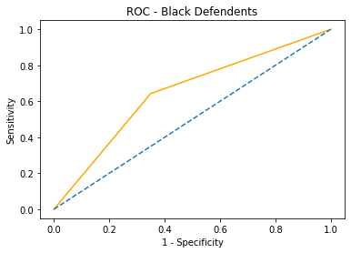

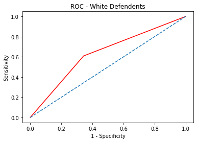

```python
# Recall tpr = tp/tp+fn and fpr=fp/(fp+tn)
from sklearn.metrics import roc_curve

# Obtain fpr, tpr, and threshold from roc_curve method
df_aa = df_predicted[df_predicted['race_African-American'] == 1]
fpr_aa, tpr_aa, threshold_aa = roc_curve(df_aa['predicted score'], df_aa['two_year_recid'])

df_w = df_predicted[df_predicted['race_Caucasian'] == 1]
fpr_w, tpr_w, threshold_w = roc_curve(df_w['predicted score'], df_w['two_year_recid'])


# Plot the ROC
#plt.subplots(1, figsize=(10,10))
plt.title('ROC - Black Defendents')
plt.ylabel('Sensitivity')
plt.xlabel('1 - Specificity')
plt.plot(fpr_aa, tpr_aa, color='orange', label="African American ROC Curve")
plt.plot([0, 1], ls="--")
plt.show()

plt.title('ROC - White Defendents')
plt.ylabel('Sensitivity')
plt.xlabel('1 - Specificity')
plt.plot(fpr_w, tpr_w, color='red', label="White ROC Curve")
plt.plot([0, 1], ls="--")
plt.show()
```

```python
# Calculate the AUC - Replace zeros with correct AUC's
from sklearn.metrics import auc
print("AUC for Black defendants:", auc(fpr_aa, tpr_aa))
print("AUC for white defendants:", auc(fpr_w, tpr_w))
```

```
AUC for Black defendants: 0.6467201478243234
AUC for white defendants: 0.6329109541614735
```

### Question 4b (i)

What do you notice from the ROC curve and the AUC calculation? List at least two general observations.

> The ROC curves are not perfect classifiers (of course) but they are better since they are far from the straight dotted blue line. The AUC calculation for both groups is around 0.65 which is a decent score, it is not the worst but also not the best, which means that our classifier is not separating either value correctly or incorrectly

### Question 4b (ii)

What could Northpointe take away from this visualization to prove their point? Is accuracy equity being represented here? (Hint: Is each racial group being discriminated against equally?)

> Northpointe can take away from this visualization to prove their point that each racial group (at least the ones that ProPublica was arguing - African American vs White Defendants) is being discriminated against equally

## Question 5. Predictive Parity: Is the likelihood of recidivism equal across groups?

In addition to the metric outlined above, Northpointe also utilized positive predictive values to explore the likelihood of defendants to reoffend, and to therefore prove that *Predictive Parity* is achieved. Predictive parity, according to [Northpointe](http://go.volarisgroup.com/rs/430-MBX-989/images/ProPublica_Commentary_Final_070616.pdf), is exhibited in a model “if the classifier obtains similar predictive values for two different groups such as blacks and whites, for example, the probability of recidivating, given a high risk score, is similar for blacks and whites.” Let’s explore how they analyzed this.

### Question 5a

Complete the following functions to calculate the positive predictive values and negative predictive values. Afterwards, apply these functions to the data of white defendants and the data of Black defendants.

```python
def ppv(race_feature, data):
    # Return the Positive Predictive Value of scores for the specified race_feature
    df_p = data[data[race_feature] == 1]
    tn, fp, fn, tp = confusion_matrix(df_p['two_year_recid'],df_p['predicted score']).ravel()
    ppv = tp/(tp+fp)
    return ppv


def npv(race_feature, data):
    # Return the Negative Predictive Value of scores for the specified race_feature
    df_p = data[data[race_feature] == 1]
    tn, fp, fn, tp = confusion_matrix( df_p['two_year_recid'], df_p['predicted score']).ravel()
    npv = tn/(tn+fn)

    return npv
```

```python
# Apply metrics to the dataset - Replace zeros with correct metrics
print("PPV for Black defendants:", ppv("race_African-American", df_predicted))
print("NPV for Black defendants:", npv("race_African-American", df_predicted))
print("PPV for white defendants:", ppv("race_Caucasian", df_predicted))
print("NPV for white defendants:", npv("race_Caucasian", df_predicted))
```

```
PPV for Black defendants: 0.6432160804020101
NPV for Black defendants: 0.6502242152466368
PPV for white defendants: 0.6091954022988506
NPV for white defendants: 0.6566265060240963
```

### Question 5b

Use the metrics you calculated above to fill in the table below.

|  | White | Black |
| --- | --- | --- |
| Labeled higher risk, but didn't reoffend | % | % |
| Labeled lower risk, but did reoffend | % | % |

```python
# Student calculations for above table

# Labeled high risk but didn't reoffend
ppv_aa = ppv("race_African-American", df_predicted)
ppv_aa = (1 - ppv_aa) * 100
ppv_w = ppv("race_Caucasian", df_predicted)
ppv_w = (1 - ppv_w) * 100

# Labeled low risk but did reoffend
npv_aa = npv("race_African-American", df_predicted)
npv_aa = (1 - npv_aa) * 100
npv_w = npv("race_Caucasian", df_predicted)
npv_w = (1 - npv_w) * 100

# Create table
table_i = {"index":["Labeled higher risk, but didn't reoffend", "Labeled lower risk, but did reoffend"]}

table = {" ":["Labeled higher risk, but didn't reoffend", "Labeled lower risk, but did reoffend"],
         "White": [ppv_w, npv_w],
         "Black": [ppv_aa, npv_aa]
        }

table_df = pd.DataFrame(table)
table_df.set_index(" ", inplace=True)
table_df
```

|  | White | Black |
| --- | --- | --- |
| Labeled higher risk, but didn't reoffend | 39.080460 | 35.678392 |
| Labeled lower risk, but did reoffend | 34.337349 | 34.977578 |

### Question 5c (i)

What do you notice about the positive predictive values for each group? List at least one general observation.

> The positive predictive values for each group are pretty much the same, around 0.65 for each group.

### Question 5c (ii)

What could Northpointe conclude from these findings? Is predictive parity represented here? (Hint: Is the likelihood of recidivism relatively equal for each racial group?)

> The likelihood of recidivism is relatively equal for each racial group. They are in the mid to high 30s. They can conclude that both racial groups have equal likelihood of recidivism and that there is no bias in their data like ProPublica's findings.

## Question 6.

### Question 6a

How would you describe Northpointe’s definition of fairness, after learning and utilizing the metrics they used? How is this different from your description of ProPublica’s definition from Q3aii?

> Northpointe's definition of fairness focuses more on the true positives as well as the false positives rather than just false negatives and false positives like ProPublica. They focus on the cases that received a high score and actually did recidivate. So both sides of the argument is similar to whether a person looks at a glass of water half empty or half full.

### Question 6b

If anything, what are ProPublica and Northpointe each not considering in their definitions? (Hint: Think about other goodness metrics in ML, as well as your knowledge of the historical context of policing data)

> I think that they are not considering that there is no actual fairness in our criminal justice system. Black people are stopped and arrested at a higher rate than Whites primarily because some Black people live in communities where they have little resources to climb up the financial ladder compared to their white counterparts. It is not only about money, power, and connections but the color of their skin matters apparently.

So far, we’ve investigated ProPublica’s and Northpointe’s definitions of fairness. In the world of machine learning there are [many more](https://www.google.com/url?q=https://fairmlbook.org/tutorial2.html&sa=D&ust=1606727018134000&usg=AOvVaw06zU_fm8h7xp71d8igA8KI), so in the next section we will take a look at a third definition.

# Part 3. Yet Another Definition of Fairness

In this section, you will go through yet another metric and definition used to evaluate fairness in machine learning: **disparate impact**. Disparate impact is a legal doctrine that determines if there is unintended discrimination towards a protected class ([Society for Human Resource Management](https://www.shrm.org/resourcesandtools/tools-and-samples/hr-qa/pages/disparateimpactdisparatetreatment.aspx)). In machine learning, disparate impact is a metric to evaluate fairness in a model. It is a form of bias within an algorithm that reflects systemic discrimination when a model’s outputs are dependent on a *sensitive feautre* (the protected class). This is often considered unintentional (like the legal doctrine) due to the fact that the sensitive feature is omitted from the model, though it is still correlated with the output through proxy variables ([Wang et al.](https://arxiv.org/pdf/1801.05398.pdf#:~:text=Abstract%E2%80%94In%20the%20context%20of,e.g.%2C%20race%20or%20gender)).

Not only will you evaluate the fairness of the tool (as Northpointe and ProPublica did) by measuring the bias reflected in the outputs of the model, but you will remove it to actually change those outputs and therefore eliminate the dependencies between the risk scores and the race feature. In order to computationally remove the disparate impact that we quantify, we can use tools like aif360’s [Disparate Impact Remover](https://aif360.readthedocs.io/en/latest/modules/generated/aif360.algorithms.preprocessing.DisparateImpactRemover.html). aif360 is a package created by IBM’s AI Research team, which contains a variety of tools to “help you examine, report, and mitigate discrimination and bias in machine learning models throughout the AI application lifecycle” ([AI Fairness 360](https://aif360.mybluemix.net/)).

## Question 7. Disparate Impact: Quantification and Removal

First, let’s visualize the disparity that we would like to remove from the dataset. In order to do that we need to distinguish between a privileged group and an unprivileged group. In technical terms, the privileged group receives higher scores from a trained model, so therefore the Black defendants will be considered "privileged" and the white defendants will be considered "unprivileged" in this case.

### Question 7a

Use a histogram to plot the scores for Black defendants and the scores for white defendants. Visualize both histograms on the same plot.

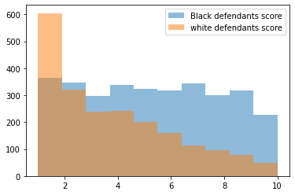

```python
# Student Code for Histogram
# Use df_predicted or df? The privileged group receives higher scores from a trained model
plt.hist(df[df['race_African-American'] == 1]['decile_score'], alpha=0.5)
plt.hist(df[df['race_Caucasian'] == 1]['decile_score'],alpha=0.5)
plt.legend(['Black defendants score', 'white defendants score'])
plt.savefig("hist1.png")
```

### Question 7b

What do you notice from the plot? (Hint: how do the distributions differ across racial groups with respect to mean, shape of distribution, etc.)

> I can notice that there is a more evenly distribution with the Black defendants across the decile scores but for white defendants, it is skewed towards the lower scores.

Now, we need to quantify the disparate impact we are seeing in the plot. In machine learning, we can understand disparate impact as the proportion of individuals that get positive outcomes (did they get a high score) for the two groups described above:

\begin{align} \Pr(Y=1|D=Unprivileged) \ / \ \Pr(Y=1|D=Privileged) \end{align}

In this equation Y is 1 if the defendant received a high score and 0 if they received a low score.

### Question 7c (i)

Create a function to calculate the proportion of individuals from a specified racial group that get positive outcomes.

```python
def proportion(data, group):
    # Returns the proportion of individuals in data from the group who recidivate
    proportion_df = data[data[group] == 1]
    proportion_df1 = proportion_df[proportion_df['decile_score'] > 4]

    return proportion_df1.count()['decile_score']
```

### Question 7c (ii)

Use this function to calculate the disparate impact, using the equation from above.

```python
# Student Code Here
proportion(df, "race_Caucasian")/proportion(df, "race_African-American")
```

```
0.3805358119190815
```

If the proportion of unprivileged individuals receiving positive outcomes to privileged individuals receiving positive outcomes is less than 80%, there is a disparate impact violation. In order to stop a trained model from replicating these biases in its output, we can now use aif360’s Disparate Impact Remover to remove the bias we just calculated.

### Question 7d

Create a Disparate Impact Remover type object and use the function fit_transform on our data. In order to do this you will need to first create a BinaryLabelDataset from our dataset to use for fit_transform. Check out the documentation [here](https://aif360.readthedocs.io/en/latest/modules/generated/aif360.datasets.BinaryLabelDataset.html#aif360.datasets.BinaryLabelDataset) to see how to implement this.

```python
from aif360.datasets import BinaryLabelDataset
# Create new DataFrame with just the necessary columns - Only numeric values for race, decile score, and two year recid

race_data = df[['decile_score','two_year_recid','race_African-American','race_Asian','race_Caucasian', 'race_Hispanic', 'race_Native American', 'race_Other']]
# The BinaryLabelDataset requires decile_scores to be continuous -->
# Use this line of code noise = np.random.normal(0, 0.1, race_data.shape[0]) to add noise to your decile_score column
# Student Code Here
noise = np.random.normal(0, 0.1, race_data.shape[0])
race_data['decile_score'] = race_data['decile_score'] + noise

race_data
bld = BinaryLabelDataset(df=race_data,label_names=['two_year_recid'], protected_attribute_names=['race_African-American', 'race_Caucasian'])
bld
```

[output not shown]

```
               instance weights     features                                   \
                                               protected attribute
                                decile_score race_African-American race_Asian
instance names
0                           1.0     1.061553                   0.0        0.0
1                           1.0     2.934871                   1.0        0.0
2                           1.0     3.963544                   1.0        0.0
3                           1.0     1.154447                   0.0        0.0
4                           1.0     6.095210                   0.0        0.0
...                         ...          ...                   ...        ...
6167                        1.0     7.085761                   1.0        0.0
6168                        1.0     2.983919                   1.0        0.0
6169                        1.0     1.020560                   0.0        0.0
6170                        1.0     1.955596                   1.0        0.0
6171                        1.0     4.016062                   0.0        0.0

                                                                       \
               protected attribute
                    race_Caucasian race_Hispanic race_Native American
instance names
0                              0.0           0.0                  0.0
1                              0.0           0.0                  0.0
2                              0.0           0.0                  0.0
3                              0.0           0.0                  0.0
4                              1.0           0.0                  0.0
...                            ...           ...                  ...
6167                           0.0           0.0                  0.0
6168                           0.0           0.0                  0.0
6169                           0.0           0.0                  0.0
6170                           0.0           0.0                  0.0
6171                           0.0           1.0                  0.0

                          labels

               race_Other
instance names
0                     1.0    0.0
1                     0.0    1.0
2                     0.0    1.0
3                     1.0    0.0
4                     0.0    1.0
...                   ...    ...
6167                  0.0    0.0
6168                  0.0    0.0
6169                  1.0    0.0
6170                  0.0    0.0
6171                  0.0    1.0

[6172 rows x 9 columns]
```

```python
# Crate Disparate Impact Remover Object
from aif360.algorithms.preprocessing import DisparateImpactRemover

disparate_ir = DisparateImpactRemover()
```

```python
# Use fit transform on the BinaryLabelDataset created
dir_output = disparate_ir.fit_transform(bld)
```